# Chapter_13

Xiaoyan Yue

1/24/2017

## 13E1 Add to the following model varying slopes on the predictor

Yi ~ Normal(mu,sigma)  
mu = a_cafe[cafe_id] + b_cafe*Xi  
a_cafe[cafe_id] ~ Normal(a,sigma_a)  
a ~ Normal(0,10)  
b_cafe ~ Normal(0,1)  
sigma ~ HalfCauchy(0,2)  
sigma_a ~ HalfCauchy(0,2)

### Adding varying slops

Yi ~ Normal(mu,sigma)  
mu = a_cafe[cafe_id] + b_cafe[cafe_id]*Xi  
c(a_cafe,b_cafe)[cafe_id] ~ MVNormal(c(a,b),S)  
S=matrix(sigma_a,0,0,sigma_b) R matrix(sigma_a,0,0,sigma_b)  
a ~ Normal(0,10)  
b ~ Normal(0,1)  
sigma ~ HalfCauchy(0,2)  
sigma_a ~ HalfCauchy(0,2)  
sigma_b ~ HalfCauchy(0,2)  
R ~ LKJcorr(2) ##13E2 Think up a context in which varying intercepts will be positively correlated with varying slopes. Provide a mechnistic explaination for correlation.

## 13M1 Repeat the cafe robot simulation from the beginning of the chapter. This time, set rho to zero, so that there is no correlation between intercepts and slops. How does the posterior distribution of the correlation reflect in the underlying simulation?

### repeat the simulation in the chapter

```r
a <- 3.5            ## average morning wait time
b <- (-1)           ## average difference afternoon wait time
sigma_a <- 1        ## std dev in intercepts
sigma_b <- 0.5      ## std dev in slopes
rho <- (-0.7)       ## correlation between intercepts and slopes

##simulate a sample of cafe for the robot, to build a 2D multivate Gaussian distribution
Mu <- c( a , b )# create a vector of two means

cov_ab <- sigma_a*sigma_b*rho#build the entire covariance matrix
Sigma <- matrix( c(sigma_a^2,cov_ab,cov_ab,sigma_b^2) , ncol=2 )

## simulate some cafes
N_cafes <- 20

## simulate their properties by sampling randomly from the multivariate Gaussian distribution
library(MASS)
set.seed(5) # used to replicate example
vary_effects <- mvrnorm( N_cafes , Mu , Sigma )
a_cafe <- vary_effects[,1]
b_cafe <- vary_effects[,2]
#simulate the observations
N_visits <- 10
afternoon <- rep(0:1,N_visits*N_cafes/2)
cafe_id <- rep( 1:N_cafes , each=N_visits )
mu <- a_cafe[cafe_id] + b_cafe[cafe_id]*afternoon
sigma <- 0.5  # std dev within cafes
wait <- rnorm( N_visits*N_cafes , mu , sigma )
d <- data.frame( cafe=cafe_id , afternoon=afternoon , wait=wait )

## fit the model for the observation data, d
m13.1 <- map2stan(
  alist(
    wait ~ dnorm( mu , sigma ),
    mu <- a_cafe[cafe] + b_cafe[cafe]*afternoon,
    c(a_cafe,b_cafe)[cafe] ~ dmvnorm2(c(a,b),sigma_cafe,Rho),
    a ~ dnorm(0,10),
    b ~ dnorm(0,10),
    sigma_cafe ~ dcauchy(0,2),
    sigma ~ dcauchy(0,2),
    Rho ~ dlkjcorr(2)
  ) ,
  data=d ,
  iter=5000 , warmup=2000 , chains=2 )
```

[output not shown]

```
##
## WARNING: No variance estimation is
##          performed for num_warmup < 20
##
##
## Chain 1, Iteration: 1 / 1 [100%]  (Sampling)
##  Elapsed Time: 4e-06 seconds (Warm-up)
##                0.000142 seconds (Sampling)
##                0.000146 seconds (Total)
```

```
## Computing WAIC
```

```
## Constructing posterior predictions
```

[output not shown]

```r
precis(m13.1,depth = 2)
```

```
##                Mean StdDev lower 0.89 upper 0.89 n_eff Rhat
## b_cafe[1]     -1.30   0.19      -1.60      -0.99  2864    1
## b_cafe[2]     -1.20   0.20      -1.52      -0.88  3517    1
## b_cafe[3]     -1.26   0.18      -1.57      -0.98  3669    1
## b_cafe[4]     -1.29   0.19      -1.60      -0.99  3725    1
## b_cafe[5]     -1.26   0.20      -1.58      -0.96  3503    1
## b_cafe[6]     -1.28   0.19      -1.59      -0.99  4225    1
## b_cafe[7]     -1.23   0.18      -1.51      -0.94  4486    1
## b_cafe[8]     -1.26   0.18      -1.52      -0.94  4259    1
## b_cafe[9]     -1.12   0.19      -1.41      -0.81  2279    1
## b_cafe[10]    -1.19   0.19      -1.50      -0.90  4179    1
## b_cafe[11]    -1.02   0.22      -1.36      -0.67  1595    1
## b_cafe[12]    -1.21   0.18      -1.50      -0.92  3970    1
## b_cafe[13]    -1.33   0.19      -1.63      -1.04  2456    1
## b_cafe[14]    -1.38   0.20      -1.70      -1.07  1277    1
## b_cafe[15]    -1.56   0.26      -1.99      -1.18   745    1
## b_cafe[16]    -1.18   0.19      -1.45      -0.86  3883    1
## b_cafe[17]    -1.15   0.20      -1.47      -0.85  3187    1
## b_cafe[18]    -1.29   0.22      -1.64      -0.95  3281    1
## b_cafe[19]    -1.03   0.22      -1.37      -0.68  1600    1
## b_cafe[20]    -1.08   0.20      -1.39      -0.77  1829    1
## a_cafe[1]      4.09   0.18       3.81       4.39  4117    1
## a_cafe[2]      2.37   0.18       2.08       2.66  4464    1
## a_cafe[3]      3.94   0.18       3.65       4.23  3241    1
## a_cafe[4]      3.45   0.18       3.16       3.72  3511    1
## a_cafe[5]      2.15   0.18       1.85       2.43  4260    1
## a_cafe[6]      4.26   0.18       3.97       4.54  2877    1
## a_cafe[7]      3.56   0.18       3.29       3.85  6000    1
## a_cafe[8]      3.79   0.18       3.52       4.08  4093    1
## a_cafe[9]      3.88   0.18       3.60       4.17  3576    1
## a_cafe[10]     3.69   0.18       3.39       3.98  2405    1
## a_cafe[11]     2.46   0.19       2.15       2.76  2797    1
## a_cafe[12]     4.08   0.18       3.81       4.38  6000    1
## a_cafe[13]     3.88   0.18       3.60       4.18  3080    1
## a_cafe[14]     3.34   0.18       3.04       3.62  3098    1
## a_cafe[15]     4.25   0.21       3.92       4.58  1118    1
## a_cafe[16]     3.59   0.18       3.31       3.89  6000    1
## a_cafe[17]     4.43   0.18       4.15       4.74  3243    1
## a_cafe[18]     6.10   0.19       5.79       6.40  4022    1
## a_cafe[19]     3.49   0.19       3.20       3.80  2584    1
## a_cafe[20]     3.89   0.18       3.61       4.19  2978    1
## a              3.72   0.22       3.38       4.06  6000    1
## b             -1.23   0.09      -1.36      -1.08  1905    1
## sigma_cafe[1]  0.92   0.17       0.66       1.16  3987    1
## sigma_cafe[2]  0.23   0.11       0.05       0.36   497    1
## sigma          0.49   0.03       0.45       0.53  6000    1
## Rho[1,1]       1.00   0.00       1.00       1.00  6000  NaN
## Rho[1,2]      -0.18   0.32      -0.72       0.29  1343    1
## Rho[2,1]      -0.18   0.32      -0.72       0.29  1343    1
## Rho[2,2]       1.00   0.00       1.00       1.00  5506    1
```

### simulate the data by setting rho to zero

```r
rho <- 0       ## correlation between intercepts and slopes

##simulate a sample of cafe for the robot, to build a 2D multivate Gaussian distribution
Mu <- c( a , b )# create a vector of two means

cov_abM1 <- sigma_a*sigma_b*rho #build the entire covariance matrix
SigmaM1 <- matrix( c(sigma_a^2,cov_abM1,cov_abM1,sigma_b^2) , ncol=2 )

## simulate some cafes
N_cafes <- 20

## simulate their properties by sampling randomly from the multivariate Gaussian distribution
vary_effectsM1 <- mvrnorm( N_cafes , Mu , SigmaM1 )
a_cafe_M1 <- vary_effectsM1[,1]
b_cafe_M1 <- vary_effectsM1[,2]

#simulate the observations
N_visits <- 10
afternoon <- rep(0:1,N_visits*N_cafes/2)
cafe_id <- rep( 1:N_cafes , each=N_visits )
mu_M1 <- a_cafe_M1[cafe_id] + b_cafe_M1[cafe_id]*afternoon
sigma <- 0.5  # std dev within cafes
wait_M1 <- rnorm( N_visits*N_cafes , mu_M1 , sigma )
d2 <- data.frame( cafe=cafe_id , afternoon=afternoon , wait=wait_M1 )

## fit the model for the observation data, d2
m13.1.M1 <- map2stan(
  alist(
    wait ~ dnorm( mu , sigma ),
    mu <- a_cafe[cafe] + b_cafe[cafe]*afternoon,
    c(a_cafe,b_cafe)[cafe] ~ dmvnorm2(c(a,b),sigma_cafe,Rho),
    a ~ dnorm(0,10),
    b ~ dnorm(0,10),
    sigma_cafe ~ dcauchy(0,2),
    sigma ~ dcauchy(0,2),
    Rho ~ dlkjcorr(2)
  ) ,
  data=d2 ,
  iter=5000 , warmup=2000 , chains=2 )
```

[output not shown]

```
## The following numerical problems occured the indicated number of times on chain 1
```

```
##                                                                        count
## Exception thrown at line 33: lkj_corr_log: y is not positive definite.     1
```

```
## When a numerical problem occurs, the Hamiltonian proposal gets rejected.
```

```
## See http://mc-stan.org/misc/warnings.html#exception-hamiltonian-proposal-rejected
```

```
## If the number in the 'count' column is small, do not ask about this message on stan-users.
```

[output not shown]

```
## The following numerical problems occured the indicated number of times on chain 2
```

```
##                                                                        count
## Exception thrown at line 33: lkj_corr_log: y is not positive definite.     1
```

```
## When a numerical problem occurs, the Hamiltonian proposal gets rejected.
```

```
## See http://mc-stan.org/misc/warnings.html#exception-hamiltonian-proposal-rejected
```

```
## If the number in the 'count' column is small, do not ask about this message on stan-users.
```

```
##
## WARNING: No variance estimation is
##          performed for num_warmup < 20
##
##
## Chain 1, Iteration: 1 / 1 [100%]  (Sampling)
##  Elapsed Time: 3e-06 seconds (Warm-up)
##                0.000121 seconds (Sampling)
##                0.000124 seconds (Total)
```

```
## Computing WAIC
```

```
## Constructing posterior predictions
```

[output not shown]

```r
precis(m13.1.M1,depth = 2)
```

```
##                Mean StdDev lower 0.89 upper 0.89 n_eff Rhat
## b_cafe[1]     -0.62   0.27      -1.04      -0.19  6000    1
## b_cafe[2]     -0.34   0.28      -0.79       0.11  6000    1
## b_cafe[3]     -1.26   0.27      -1.68      -0.83  6000    1
## b_cafe[4]     -1.74   0.29      -2.20      -1.27  6000    1
## b_cafe[5]     -0.48   0.27      -0.90      -0.04  6000    1
## b_cafe[6]     -0.50   0.27      -0.91      -0.04  6000    1
## b_cafe[7]     -0.92   0.26      -1.31      -0.48  6000    1
## b_cafe[8]     -1.00   0.28      -1.47      -0.56  6000    1
## b_cafe[9]     -1.29   0.27      -1.75      -0.89  6000    1
## b_cafe[10]    -0.64   0.26      -1.08      -0.23  6000    1
## b_cafe[11]    -1.33   0.28      -1.78      -0.90  6000    1
## b_cafe[12]    -0.85   0.27      -1.26      -0.41  6000    1
## b_cafe[13]    -1.25   0.27      -1.69      -0.84  6000    1
## b_cafe[14]    -0.58   0.28      -1.00      -0.11  6000    1
## b_cafe[15]    -1.00   0.27      -1.44      -0.59  6000    1
## b_cafe[16]    -1.31   0.28      -1.76      -0.89  6000    1
## b_cafe[17]    -1.12   0.27      -1.56      -0.69  6000    1
## b_cafe[18]    -1.03   0.25      -1.44      -0.64  6000    1
## b_cafe[19]    -1.25   0.27      -1.70      -0.85  6000    1
## b_cafe[20]    -0.49   0.32      -1.00       0.00  4045    1
## a_cafe[1]      4.67   0.21       4.34       4.99  6000    1
## a_cafe[2]      3.87   0.21       3.56       4.24  6000    1
## a_cafe[3]      3.33   0.21       3.00       3.67  6000    1
## a_cafe[4]      2.56   0.22       2.20       2.88  6000    1
## a_cafe[5]      4.31   0.21       3.96       4.62  6000    1
## a_cafe[6]      3.96   0.21       3.62       4.29  6000    1
## a_cafe[7]      4.27   0.20       3.96       4.60  6000    1
## a_cafe[8]      4.99   0.22       4.65       5.34  6000    1
## a_cafe[9]      3.39   0.21       3.05       3.71  6000    1
## a_cafe[10]     3.91   0.21       3.58       4.25  6000    1
## a_cafe[11]     2.84   0.21       2.52       3.18  6000    1
## a_cafe[12]     3.15   0.21       2.84       3.50  6000    1
## a_cafe[13]     2.83   0.21       2.51       3.17  6000    1
## a_cafe[14]     5.23   0.21       4.88       5.57  6000    1
## a_cafe[15]     3.69   0.21       3.36       4.03  6000    1
## a_cafe[16]     3.92   0.21       3.59       4.27  6000    1
## a_cafe[17]     3.35   0.21       3.02       3.67  6000    1
## a_cafe[18]     3.56   0.20       3.25       3.89  6000    1
## a_cafe[19]     3.13   0.21       2.78       3.45  6000    1
## a_cafe[20]     2.14   0.23       1.80       2.54  6000    1
## a              3.65   0.21       3.32       3.97  6000    1
## b             -0.95   0.14      -1.17      -0.73  6000    1
## sigma_cafe[1]  0.88   0.17       0.63       1.14  6000    1
## sigma_cafe[2]  0.49   0.13       0.28       0.70  2814    1
## sigma          0.53   0.03       0.48       0.58  6000    1
## Rho[1,1]       1.00   0.00       1.00       1.00  6000  NaN
## Rho[1,2]       0.23   0.25      -0.15       0.65  3748    1
## Rho[2,1]       0.23   0.25      -0.15       0.65  3748    1
## Rho[2,2]       1.00   0.00       1.00       1.00  6000    1
```

## look at the posterior distribution of the correlation

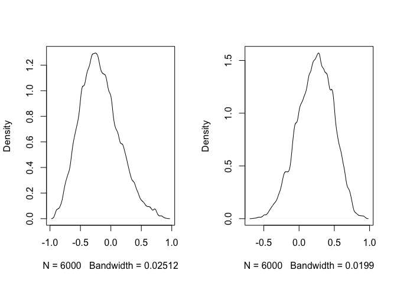

```r
par(mfrow=c(1,2))
post1 <- extract.samples(m13.1)
dens( post1$Rho[,1,2] )
post2 <- extract.samples(m13.1.M1)
dens( post2$Rho[,1,2] )
```

## 13M2 Fit the mutilevel model to the simulated cafe data

```r
m13.1.M2 <- map2stan(
  alist(
    wait ~ dnorm( mu , sigma ),
    mu <- a_cafe[cafe] + b_cafe[cafe]*afternoon,
    a_cafe[cafe] ~ dnorm(a,sigma_a),
    b_cafe[cafe] ~ dnorm(b,sigma_b),
    a ~ dnorm(0,10),
    b ~ dnorm(0,10),
    sigma_a ~ dcauchy(0,1),
    sigma_b ~ dcauchy(0,1),
    sigma ~ dcauchy(0,1)
  ) ,
  data=d ,
  iter=5000 , warmup=2000 , chains=2 )
```

[output not shown]

```
##
## WARNING: No variance estimation is
##          performed for num_warmup < 20
##
##
## Chain 1, Iteration: 1 / 1 [100%]  (Sampling)
##  Elapsed Time: 4e-06 seconds (Warm-up)
##                7.5e-05 seconds (Sampling)
##                7.9e-05 seconds (Total)
```

```
## Computing WAIC
```

```
## Constructing posterior predictions
```

[output not shown]

# compare this model to the model from the chapter

```r
#WAIC(m13.1, m13.1.M2)
#Error in UseMethod("WAIC") : no applicable method for 'WAIC' applied to an object of class "map2stan"
compare(m13.1, m13.1.M2) #looks almost the same
```

```
##           WAIC pWAIC dWAIC weight    SE  dSE
## m13.1.M2 308.4  26.5   0.0   0.61 20.05   NA
## m13.1    309.4  27.0   0.9   0.39 20.10 0.75
```

## 13M3 Using a non-centered parameterization, to re-estimate the varing slops model for UCBadmit data

### repeat the varing slops model in the chapter

```r
data(UCBadmit)
d <- UCBadmit
d$male <- ifelse( d$applicant.gender=="male" , 1 , 0 )
d$dept_id <- coerce_index( d$dept )
colnames(d) <- sub(".","_",colnames(d),fixed = TRUE)

m13.3 <- map2stan(
  alist(
    admit ~ dbinom( applications , p ),
    logit(p) <- a_dept[dept_id] +
      bm_dept[dept_id]*male,
    c(a_dept,bm_dept)[dept_id] ~ dmvnorm2( c(a,bm) , sigma_dept , Rho ),
    a ~ dnorm(0,10),
    bm ~ dnorm(0,1),
    sigma_dept ~ dcauchy(0,2),
    Rho ~ dlkjcorr(2)
  ) ,
  data=d , warmup=1000 , iter=5000 , chains=4 , cores=3 )
```

[output not shown]

```
##
## WARNING: No variance estimation is
##          performed for num_warmup < 20
##
##
## Chain 1, Iteration: 1 / 1 [100%]  (Sampling)
##  Elapsed Time: 3e-06 seconds (Warm-up)
##                7.8e-05 seconds (Sampling)
##                8.1e-05 seconds (Total)
```

```
## Computing WAIC
```

```
## Constructing posterior predictions
```

[output not shown]

```
## Aggregated binomial counts detected. Splitting to 0/1 outcome for WAIC calculation.
```

## non-centered parameterization

```r
m13.3.NC <- map2stan(
  alist(
    admit ~ dbinom( applications , p ),
    logit(p) <- a + a_dept[dept_id] + bm * male +
      bm_dept[dept_id]*male,
    c(a_dept,bm_dept)[dept_id] ~ dmvnormNC( sigma_dept , Rho ),
    a ~ dnorm(0,10),
    bm ~ dnorm(0,1),
    sigma_dept ~ dcauchy(0,2),
    Rho ~ dlkjcorr(2)
  ) ,
  data=d , warmup=1000 , iter=5000 , chains=4 , cores=3 )
```

[output not shown]

```
##
## WARNING: No variance estimation is
##          performed for num_warmup < 20
##
##
## Chain 1, Iteration: 1 / 1 [100%]  (Sampling)
##  Elapsed Time: 5e-06 seconds (Warm-up)
##                7.3e-05 seconds (Sampling)
##                7.8e-05 seconds (Total)
```

```
## Computing WAIC
```

```
## Constructing posterior predictions
```

[output not shown]

```
## Aggregated binomial counts detected. Splitting to 0/1 outcome for WAIC calculation.
```

## extract n_eff values for each model

```r
neff_c <- precis(m13.3,2)@output$n_eff
neff_c
```

```
##  [1]  4189.445 10007.855  9881.163 12747.736  8167.071 10693.149  5117.732
##  [8] 10147.957 10852.067 13188.889  4389.116 10839.845  9854.363  9909.219
## [15]  9038.032  5905.413 16000.000 10235.380 10235.380 15440.779
```

```r
neff_nc <- precis(m13.3.NC,2)@output$n_eff
neff_nc
```

```
##  [1]  5466.503  5675.417  4572.462  4601.287  4520.472  4652.765 10356.720
##  [8] 12179.468  9941.136  9285.987  9743.905 11164.662 16000.000 16000.000
## [15] 10954.310  9542.997  4306.074  4915.215  4385.445  5033.602  4474.952
## [22]  4909.091  4339.095  4374.161  4403.627  4623.850  5912.601 11682.557
## [29]  6141.476  5465.024  6666.146  8871.097 16000.000 10954.310 10954.310
## [36] 15599.304
```

## plot distributions

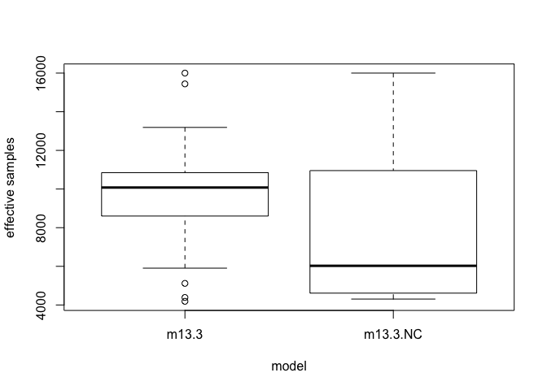

```r
boxplot( list( 'm13.3'=neff_c , 'm13.3.NC'=neff_nc ) ,
         ylab="effective samples" , xlab="model" )
```

## 13H1 Revisit the Bangladesh fertility data

```r
#load the data
data("bangladesh")
summary(bangladesh)
```

```
##      woman           district     use.contraception living.children
##  Min.   :   1.0   Min.   : 1.00   Min.   :0.0000    Min.   :1.000
##  1st Qu.: 484.2   1st Qu.:14.00   1st Qu.:0.0000    1st Qu.:1.000
##  Median : 967.5   Median :29.00   Median :0.0000    Median :3.000
##  Mean   : 967.5   Mean   :29.35   Mean   :0.3925    Mean   :2.652
##  3rd Qu.:1450.8   3rd Qu.:45.00   3rd Qu.:1.0000    3rd Qu.:4.000
##  Max.   :1934.0   Max.   :61.00   Max.   :1.0000    Max.   :4.000
##   age.centered            urban
##  Min.   :-13.560000   Min.   :0.0000
##  1st Qu.: -7.559900   1st Qu.:0.0000
##  Median : -1.559900   Median :0.0000
##  Mean   :  0.002198   Mean   :0.2906
##  3rd Qu.:  6.440000   3rd Qu.:1.0000
##  Max.   : 19.440000   Max.   :1.0000
```

```r
bangladesh$district_id <- coerce_index( bangladesh$district )
names(bangladesh) <- sub(".","_",fixed = TRUE,names(bangladesh))

###fit the model with varying slops
m13H1 <- map2stan(
  alist(
    use_contraception ~ dnorm( mu , sigma ),
    mu <- a_district[district_id] + b_district[district_id]*urban,
    c(a_district,b_district)[district_id] ~ dmvnorm2(c(a,b),sigma_district,Rho),
    a ~ dnorm(0,10),
    b ~ dnorm(0,10),
    sigma_district ~ dcauchy(0,2),
    sigma ~ dcauchy(0,2),
    Rho ~ dlkjcorr(2)
  ) ,
  data=bangladesh ,
  iter=5000 , warmup=2000 , chains=2 )
```

[output not shown]

```
## The following numerical problems occured the indicated number of times on chain 1
```

```
##                                                                        count
## Exception thrown at line 33: lkj_corr_log: y is not positive definite.     3
```

```
## When a numerical problem occurs, the Hamiltonian proposal gets rejected.
```

```
## See http://mc-stan.org/misc/warnings.html#exception-hamiltonian-proposal-rejected
```

```
## If the number in the 'count' column is small, do not ask about this message on stan-users.
```

[output not shown]

```
## The following numerical problems occured the indicated number of times on chain 2
```

```
##                                                                        count
## Exception thrown at line 33: lkj_corr_log: y is not positive definite.     3
```

```
## When a numerical problem occurs, the Hamiltonian proposal gets rejected.
```

```
## See http://mc-stan.org/misc/warnings.html#exception-hamiltonian-proposal-rejected
```

```
## If the number in the 'count' column is small, do not ask about this message on stan-users.
```

```
##
## WARNING: No variance estimation is
##          performed for num_warmup < 20
##
##
## Chain 1, Iteration: 1 / 1 [100%]  (Sampling)
##  Elapsed Time: 4e-06 seconds (Warm-up)
##                0.000495 seconds (Sampling)
##                0.000499 seconds (Total)
```

```
## Computing WAIC
```

```
## Constructing posterior predictions
```

[output not shown]

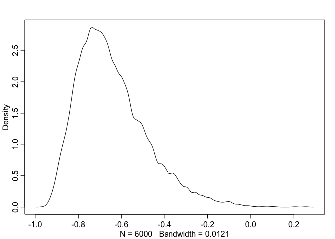

```r
###Inspect the correlation between the intercept and slopes
post <- extract.samples(m13H1)
dens( post$Rho[,1,2])
```

###Plot the mean varying effect estimates for both the intercepts and slopes by district

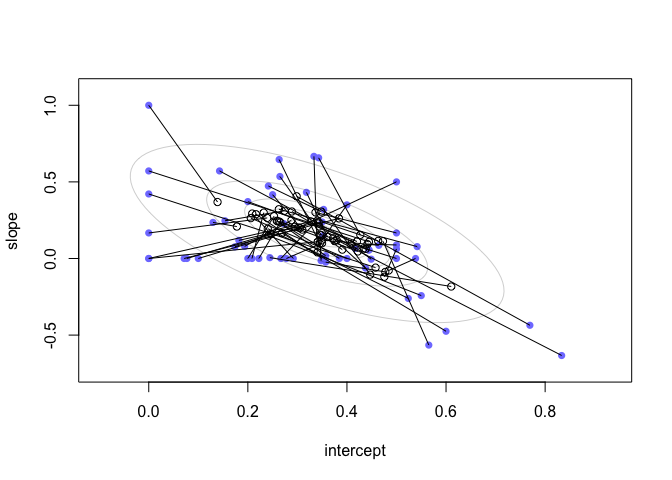

```r
#### compute unpooled estimates directly from data

a1 <- sapply( c(unique(bangladesh$district_id)) ,
              function(i) mean(bangladesh$use_contraception[bangladesh$district_id==i & bangladesh$urban==0]) )
a1[is.nan(a1)] <- 0 #some NaN in data making some errors later

b1 <- sapply( c(unique(bangladesh$district_id)) ,
              function(i) mean(bangladesh$use_contraception[bangladesh$district_id==i & bangladesh$urban==1]) ) - a1
b1[is.nan(b1)] <- 0
#### compute mean of partially pooled estimates
a2 <- apply(post$a_district,2,mean)
b2 <- apply(post$b_district,2,mean)

#### plot both and connect with lines
plot( a1 , b1 , xlab="intercept" , ylab="slope" ,
      pch=16 , col=rangi2 , ylim=c( min(b1)-0.1 , max(b1)+0.1 ) ,
      xlim=c( min(a1)-0.1 , max(a1)+0.1 ) )
points( a2 , b2 , pch=1 )
for ( i in c(unique(bangladesh$district_id)) ) lines( c(a1[i],a2[i]) , c(b1[i],b2[i]) )

#compute posterior mean bivariate Gaussian
Mu_est <- c( mean(post$a) , mean(post$b) )
rho_est <- mean( post$Rho[,1,2] )
sa_est <- mean( post$sigma_district[,1] )
sb_est <- mean( post$sigma_district[,2] )
cov_ab <- sa_est*sb_est*rho_est
Sigma_est <- matrix( c(sa_est^2,cov_ab,cov_ab,sb_est^2) , ncol=2 )

# draw contours
library(ellipse)
for ( l in c(0.1,0.3,0.5,0.8,0.99) )
  lines(ellipse(Sigma_est,centre=Mu_est,level=l),
        col=col.alpha("black",0.2))
```

###Plot predicted proportion of woman using contraception, with urban woman on one axies and rural on the other

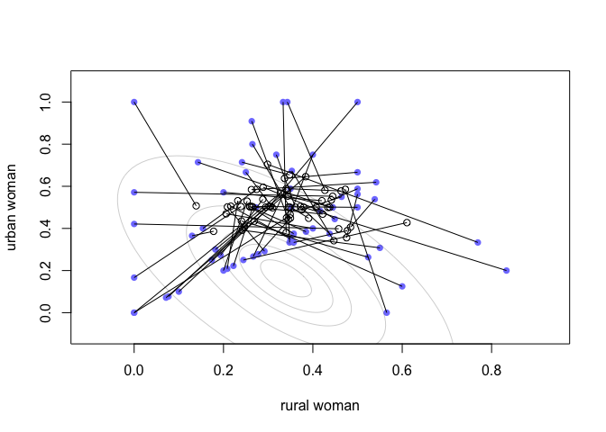

```r
## convert varying effects to the proportion of woman using contraception
use_contraception_rural_1 <- (a1)
use_contraception_urban_1 <- (a1 + b1)

use_contraception_rural_2 <- (a2)
use_contraception_urban_2 <- (a2 + b2)

# plot both and connect with lines
plot( use_contraception_rural_1 , use_contraception_urban_1 , xlab="rural woman" , ylab="urban woman" ,
      pch=16 , col=rangi2 , ylim=c( min(use_contraception_urban_1)-0.1 , max(use_contraception_urban_1)+0.1 ) ,
      xlim=c( min(use_contraception_rural_1)-0.1 , max(use_contraception_rural_1)+0.1 ) )
points( use_contraception_rural_2 , use_contraception_urban_2 , pch=1 )
for ( i in c(unique(bangladesh$district_id)) ) lines( c(use_contraception_rural_1[i],use_contraception_rural_2[i]) , c(use_contraception_urban_1[i],use_contraception_urban_2[i]) )

#compute posterior mean bivariate Gaussian
Mu_est <- c( mean(post$a) , mean(post$b) )
rho_est <- mean( post$Rho[,1,2] )
sa_est <- mean( post$sigma_district[,1] )
sb_est <- mean( post$sigma_district[,2] )
cov_ab <- sa_est*sb_est*rho_est
Sigma_est <- matrix( c(sa_est^2,cov_ab,cov_ab,sb_est^2) , ncol=2 )

#draw contours
library(ellipse)
for ( l in c(0.1,0.3,0.5,0.8,0.99) )
  lines(ellipse(Sigma_est,centre=Mu_est,level=l),
        col=col.alpha("black",0.2))
```

## Try to fit the varing slopes model for my own data

### Let’s look at the whole data

```r
#load the data
RSA_Jan <- read.csv("/Users/xyyue/Documents/Phosphrous_project/Data_Jan6th/results_rsa_all.csv")

#subset the data for primary root length
RSA_Jan_Proot <- RSA_Jan[,c("length","treatment","sample")] #length, which is the primary root length

#look at the data
head(RSA_Jan_Proot)
```

```
##      length treatment sample
## 1  1.698664 P_limited   Penn
## 2  2.117296 P_limited   Penn
## 3 11.513583 P_limited   Penn
## 4 11.638615 P_limited IL11.2
## 5 10.552052 P_limited IL11.2
## 6 12.348566 P_limited IL11.2
```

```r
str(RSA_Jan_Proot)
```

```
## 'data.frame':    341 obs. of  3 variables:
##  $ length   : num  1.7 2.12 11.51 11.64 10.55 ...
##  $ treatment: Factor w/ 2 levels "P_limited","P_sufficient": 1 1 1 1 1 1 1 1 1 1 ...
##  $ sample   : Factor w/ 76 levels "IL1.1","IL1.1.2",..: 76 76 76 14 14 14 3 68 68 70 ...
```

```r
summary(RSA_Jan_Proot)
```

```
##      length              treatment        sample
##  Min.   : 1.699   P_limited   :177   Penn    : 10
##  1st Qu.:10.919   P_sufficient:164   IL11.2  :  8
##  Median :12.798                      IL1.1   :  6
##  Mean   :12.468                      IL1.2   :  6
##  3rd Qu.:14.375                      IL1.4.18:  6
##  Max.   :17.495                      IL10.1  :  6
##                                      (Other) :299
```

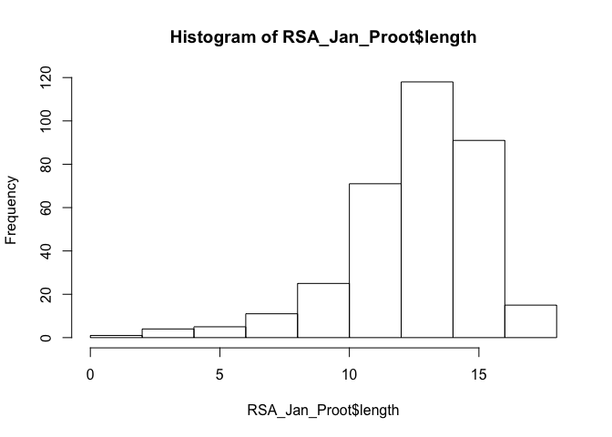

```r
hist(RSA_Jan_Proot$length)
```

###Plot the raw data (it looks so crowded,how can I split them into several subsets?)

[figure not shown]

```r
###set the reference
RSA_Jan$sample <- relevel(RSA_Jan$sample,ref = "M82")
RSA_Jan$treatment <- relevel(RSA_Jan$treatment,ref = "P_sufficient")

source("/Users/xyyue/function.R")
p <- ggplot(data=RSA_Jan,aes(x=treatment,y=length,color=treatment))
p <- p + geom_jitter()
p <- p + stat_summary(fun.y="mean",geom="bar",alpha=0.5)
p <- p + stat_summary(fun.data="calc.sem",geom="errorbar",position="dodge")
p <- p + facet_grid(.~sample)
p <- p + labs(title="Primary Root Length")
p
```

### fit model by map2stan

#### fit the model with varing slopes

```r
RSA_Jan_Proot$P_limited <- ifelse( RSA_Jan_Proot$treatment=="P_limited" , 1 , 0 )
RSA_Jan_Proot$genotype_id <- coerce_index( RSA_Jan_Proot$sample)

m_rsa_pl.with <- map2stan(
  alist(
    length ~ dnorm( mu , sigma ),
    mu <- a_genotype[genotype_id] + b_genotype[genotype_id]*P_limited,
    c(a_genotype,b_genotype)[genotype_id] ~ dmvnorm2(c(a,b),sigma_genotype,Rho),
    a ~ dnorm(10,20),
    b ~ dnorm(0,10),
    sigma_genotype ~ dcauchy(0,2),
    sigma ~ dcauchy(0,2),
    Rho ~ dlkjcorr(2)
  ) ,
  data=RSA_Jan_Proot , warmup=1000 , iter=5000 , chains=4 , cores=3 )
```

[output not shown]

```
##
## WARNING: No variance estimation is
##          performed for num_warmup < 20
##
##
## Chain 1, Iteration: 1 / 1 [100%]  (Sampling)
##  Elapsed Time: 5e-06 seconds (Warm-up)
##                0.000371 seconds (Sampling)
##                0.000376 seconds (Total)
```

```
## Computing WAIC
```

```
## Constructing posterior predictions
```

[output not shown]

### Inspect the correlation between the intercept and slopes

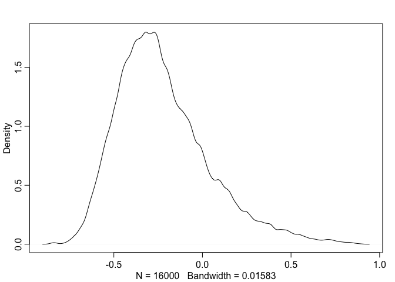

```r
post <- extract.samples(m_rsa_pl.with)
dens( post$Rho[,1,2])
```

### Plot the mean varying effect estimates for both the intercepts and slopes by genotypes

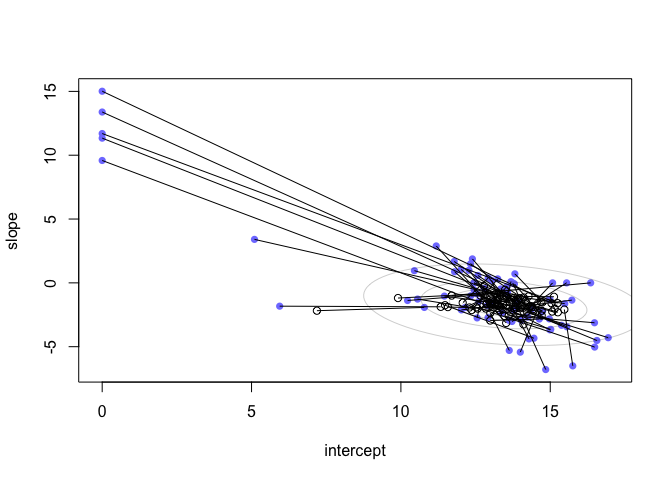

```r
#### compute unpooled estimates directly from data
a1 <- sapply( c(unique(RSA_Jan_Proot$genotype_id)) ,
              function(i) mean(RSA_Jan_Proot$length[RSA_Jan_Proot$genotype_id==i & RSA_Jan_Proot$P_limited==0]) )
a1[is.nan(a1)] <- 0 #some NaN in data making some errors later

b1 <- sapply( c(unique(RSA_Jan_Proot$genotype_id)) ,
              function(i) mean(RSA_Jan_Proot$length[RSA_Jan_Proot$genotype_id==i & RSA_Jan_Proot$P_limited==1]) ) - a1
b1[is.nan(b1)] <- 0
#### compute mean of partially pooled estimates
a2 <- apply(post$a_genotype,2,mean)
b2 <- apply(post$b_genotype,2,mean)

#### plot both and connect with lines
plot( a1 , b1 , xlab="intercept" , ylab="slope" ,
      pch=16 , col=rangi2 , ylim=c( min(b1)-0.1 , max(b1)+0.1 ) ,
      xlim=c( min(a1)-0.1 , max(a1)+0.1 ) )
points( a2 , b2 , pch=1 )
for ( i in c(unique(RSA_Jan_Proot$genotype_id)) ) lines( c(a1[i],a2[i]) , c(b1[i],b2[i]) )

#compute posterior mean bivariate Gaussian
Mu_est <- c( mean(post$a) , mean(post$b) )
rho_est <- mean( post$Rho[,1,2] )
sa_est <- mean( post$sigma_genotype[,1] )
sb_est <- mean( post$sigma_genotype[,2] )
cov_ab <- sa_est*sb_est*rho_est
Sigma_est <- matrix( c(sa_est^2,cov_ab,cov_ab,sb_est^2) , ncol=2 )

# draw contours
library(ellipse)
for ( l in c(0.1,0.3,0.5,0.8,0.99) )
  lines(ellipse(Sigma_est,centre=Mu_est,level=l),
        col=col.alpha("black",0.2))
```

### look into the model

```r
precis(m_rsa_pl.with,depth = 2)
```

```
##                    Mean StdDev lower 0.89 upper 0.89 n_eff Rhat
## b_genotype[1]     -1.88   0.88      -3.33      -0.52 16000 1.00
## b_genotype[2]     -1.76   0.90      -3.20      -0.32 16000 1.00
## b_genotype[3]     -2.36   1.04      -4.10      -0.85 16000 1.00
## b_genotype[4]     -0.97   0.93      -2.38       0.51  2462 1.00
## b_genotype[5]     -2.03   0.98      -3.66      -0.53 16000 1.00
## b_genotype[6]     -1.75   0.92      -3.24      -0.31 16000 1.00
## b_genotype[7]     -1.15   0.89      -2.58       0.25 16000 1.00
## b_genotype[8]     -1.02   0.91      -2.44       0.45 16000 1.00
## b_genotype[9]     -1.66   0.90      -3.06      -0.18 16000 1.00
## b_genotype[10]    -1.93   0.90      -3.37      -0.48 16000 1.00
## b_genotype[11]    -2.13   0.88      -3.49      -0.71 16000 1.00
## b_genotype[12]    -1.59   0.92      -3.03      -0.09 16000 1.00
## b_genotype[13]    -1.90   1.12      -3.73      -0.19 16000 1.00
## b_genotype[14]    -1.82   0.82      -3.11      -0.49 16000 1.00
## b_genotype[15]    -1.83   0.96      -3.34      -0.27 16000 1.00
## b_genotype[16]    -2.02   0.98      -3.58      -0.43 16000 1.00
## b_genotype[17]    -2.09   0.95      -3.68      -0.65 16000 1.00
## b_genotype[18]    -1.99   0.90      -3.40      -0.53 16000 1.00
## b_genotype[19]    -1.09   1.12      -2.75       0.80  3663 1.00
## b_genotype[20]    -2.09   0.91      -3.51      -0.61 16000 1.00
## b_genotype[21]    -1.75   0.85      -3.07      -0.36 16000 1.00
## b_genotype[22]    -1.30   0.88      -2.58       0.21 16000 1.00
## b_genotype[23]    -1.19   0.99      -2.71       0.41 16000 1.00
## b_genotype[24]    -1.18   0.96      -2.65       0.36 16000 1.00
## b_genotype[25]    -1.00   1.04      -2.57       0.66 16000 1.00
## b_genotype[26]    -1.00   1.01      -2.51       0.62  2127 1.00
## b_genotype[27]    -0.84   0.97      -2.29       0.70  1714 1.00
## b_genotype[28]    -1.41   0.89      -2.80       0.05 16000 1.00
## b_genotype[29]    -1.41   0.98      -2.96       0.17 16000 1.00
## b_genotype[30]    -1.85   0.96      -3.47      -0.37 16000 1.00
## b_genotype[31]    -2.19   0.95      -3.75      -0.75 16000 1.00
## b_genotype[32]    -1.62   0.85      -2.91      -0.19 16000 1.00
## b_genotype[33]    -1.78   0.97      -3.37      -0.27 16000 1.00
## b_genotype[34]    -2.57   0.96      -4.04      -1.05  1927 1.00
## b_genotype[35]    -2.01   0.94      -3.53      -0.53 16000 1.00
## b_genotype[36]    -1.58   0.93      -3.14      -0.14 16000 1.00
## b_genotype[37]    -1.90   1.00      -3.53      -0.33 16000 1.00
## b_genotype[38]    -1.49   0.91      -2.98      -0.08 16000 1.00
## b_genotype[39]    -1.64   0.94      -3.09      -0.10 16000 1.00
```

[output cut: 107 more lines]

```
## a_genotype[71]    14.71   0.92      13.30      16.21 16000 1.00
## a_genotype[72]    13.65   0.83      12.30      14.96 16000 1.00
## a_genotype[73]    12.78   0.87      11.42      14.19  2293 1.00
## a_genotype[74]    12.99   0.84      11.69      14.36 16000 1.00
## a_genotype[75]    13.47   0.81      12.18      14.72 16000 1.00
## a_genotype[76]     7.19   0.82       5.89       8.51  6638 1.00
## a                 13.45   0.23      13.08      13.83  7513 1.00
## b                 -1.71   0.25      -2.10      -1.32  4434 1.00
## sigma_genotype[1]  1.55   0.21       1.22       1.89  2376 1.00
## sigma_genotype[2]  1.05   0.39       0.40       1.66   344 1.01
## sigma              1.84   0.09       1.68       1.98  1519 1.00
## Rho[1,1]           1.00   0.00       1.00       1.00 16000  NaN
## Rho[1,2]          -0.22   0.26      -0.62       0.16   878 1.00
## Rho[2,1]          -0.22   0.26      -0.62       0.16   878 1.00
## Rho[2,2]           1.00   0.00       1.00       1.00 15413 1.00
```

### fit the model without varing slopes

```r
m_rsa_pl.without <- map2stan(
  alist(
    length ~ dnorm( mu , sigma ),
    mu <- a_genotype[genotype_id] + bT*P_limited,
    a_genotype[genotype_id] ~ dnorm(a,sigma_genotype),
    a ~ dnorm(10,20),
    bT ~ dnorm(0,10),
    sigma_genotype ~ dcauchy(0,2),
    sigma ~ dcauchy(0,2)
  ) ,
  data=RSA_Jan_Proot , warmup=1000 , iter=5000 , chains=4 , cores=3 )
```

[output not shown]

```
## Computing WAIC
```

```
## Constructing posterior predictions
```

[output not shown]

### compare two models

```r
compare(m_rsa_pl.with,m_rsa_pl.without)
```

```
##                    WAIC pWAIC dWAIC weight    SE  dSE
## m_rsa_pl.with    1460.7  67.9   0.0   0.99 32.81   NA
## m_rsa_pl.without 1471.3  49.8  10.5   0.01 30.84 6.56
```

### fit the model by brms

```r
RSA_Jan_Proot$sample <- relevel(RSA_Jan_Proot$sample,ref = "M82")
RSA_Jan_Proot$treatment <- relevel(RSA_Jan_Proot$treatment,ref = "P_sufficient")

m_rsa_pl.brms <- brm(length ~ sample * treatment ,#the average of random effect is 0, so the estimate is the standard deviation
            data = RSA_Jan_Proot,
            prior = c(
              set_prior("normal(10,20)",class="Intercept"),
              set_prior("normal(0,10)",class="b"),
              set_prior("cauchy(0,2)", class = "sigma"))) #half cauchy prior for sigma))#sets the same prior for beta coefficients, the others are as default
summary(m_rsa_pl.brms)
```

```
##  Family: gaussian (identity)
## Formula: length ~ sample * treatment
##    Data: RSA_Jan_Proot (Number of observations: 341)
## Samples: 4 chains, each with iter = 2000; warmup = 1000; thin = 1;
##          total post-warmup samples = 4000
##    WAIC: Not computed
##
## Population-Level Effects:
##                                   Estimate Est.Error l-95% CI u-95% CI
## Intercept                            13.46      0.68    12.14    14.80
## sampleIL1.1                          -2.65      1.21    -5.01    -0.26
## sampleIL1.1.2                         0.92      1.41    -1.76     3.69
## sampleIL1.1.3                         0.11      1.45    -2.71     2.88
## sampleIL1.2                          -0.85      1.22    -3.26     1.47
## sampleIL1.3                           1.49      1.85    -2.10     5.10
## sampleIL1.4                          -2.84      1.40    -5.65     0.03
## sampleIL1.4.18                        0.35      1.22    -2.01     2.80
## sampleIL10.1                         -0.48      1.25    -2.90     2.03
## sampleIL10.1.1                       -0.82      1.21    -3.24     1.55
## sampleIL10.2                         -1.40      1.40    -4.18     1.32
## sampleIL10.2.2                        0.15      1.23    -2.27     2.56
## sampleIL10.3                          2.24      1.22    -0.10     4.68
## sampleIL11.1                          1.60      1.42    -1.19     4.33
## sampleIL11.2                          1.28      1.20    -1.03     3.62
## sampleIL11.3                         -0.07      1.22    -2.46     2.36
## sampleIL11.4                         -0.88      1.87    -4.61     2.72
## sampleIL11.4.1                        2.99      1.22     0.61     5.43
## sampleIL12.1                          1.17      1.43    -1.57     3.94
## sampleIL12.1.1                        2.06      7.21   -11.94    16.34
## sampleIL12.2                          0.28      1.23    -2.14     2.67
## sampleIL12.3                         -0.54      1.23    -2.98     1.80
## sampleIL12.3.1                       -0.63      1.25    -3.14     1.86
## sampleIL12.4                         -1.26      1.86    -4.84     2.52
## sampleIL12.4.1                       -0.16      1.40    -2.91     2.63
## sampleIL2.1                          -1.61      1.20    -3.89     0.76
## sampleIL2.1.1                        -2.94      1.24    -5.38    -0.55
## sampleIL2.2                          -1.14      1.22    -3.55     1.26
## sampleIL2.3                          -0.93      1.43    -3.78     1.77
## sampleIL2.4                           0.32      1.42    -2.39     3.10
## sampleIL2.5                           1.46      1.85    -2.09     5.15
```

[output cut: 267 more lines]

```
## sampleIL9.1.3:treatmentP_limited        4000 1.00
## sampleIL9.2:treatmentP_limited          4000 1.00
## sampleIL9.2.5:treatmentP_limited        4000 1.00
## sampleIL9.2.6:treatmentP_limited        4000 1.00
## sampleIL9.3.1:treatmentP_limited        4000 1.00
## sampleIL9.3.2:treatmentP_limited        4000 1.00
## samplePenn:treatmentP_limited           1208 1.00
##
## Family Specific Parameters:
##       Estimate Est.Error l-95% CI u-95% CI Eff.Sample Rhat
## sigma      1.8      0.09     1.64     1.99       4000    1
##
## Samples were drawn using sampling(NUTS). For each parameter, Eff.Sample
## is a crude measure of effective sample size, and Rhat is the potential
## scale reduction factor on split chains (at convergence, Rhat = 1).
```

## 13M4 Use WAIC to compare the Gaussian process model of Oceanic tools to the models fit to the same data in Chapter 10.

### Repeat the model with Gaussian process in Chapter 13

```r
data(islandsDistMatrix)

data(Kline2) # load the ordinary data, now with coordinates
d <- Kline2
d$society <- 1:10 # index observations

m13.7 <- map2stan(
  alist(
    total_tools ~ dpois(lambda),
    log(lambda) <- a + g[society] + bp*logpop,
    g[society] ~ GPL2( Dmat , etasq , rhosq , 0.01 ),
    a ~ dnorm(0,10),
    bp ~ dnorm(0,1),
    etasq ~ dcauchy(0,1),
    rhosq ~ dcauchy(0,1)
  ),
  data=list(
    total_tools=d$total_tools,
    logpop=d$logpop,
    society=d$society,
    Dmat=islandsDistMatrix),
  warmup=2000 , iter=1e4 , chains=4 )
```

[output not shown]

[output cut: 42 more lines]

[output not shown]

```
## Computing WAIC
```

```
## Constructing posterior predictions
```

[output not shown]

### Repeat the model in Chapter 10

```r
# log the population
d$log_pop <- log(d$population)
# dummy variable
d$contact_high <- ifelse( d$contact=="high" , 1 , 0 )

m10.10 <- map(
  alist(
    total_tools ~ dpois( lambda ),
    log(lambda) <- a + bp*log_pop +
      bc*contact_high + bpc*contact_high*log_pop,
    a ~ dnorm(0,100),
    c(bp,bc,bpc) ~ dnorm(0,1)
  ),
  data=d )

m10.10stan <- map2stan( m10.10 , iter=3000 , warmup=1000 , chains=4 )
```

[output not shown]

[output cut: 42 more lines]

[output not shown]

```
## Computing WAIC
```

```
## Constructing posterior predictions
```

[output not shown]

### Repeat the model in Chapter 10 with centered predictor

```r
# construct centered predictor
d$log_pop_c <- d$log_pop - mean(d$log_pop)

# re-estimate
m10.10stan.c <- map2stan(
  alist(
    total_tools ~ dpois( lambda ) ,
    log(lambda) <- a + bp*log_pop_c + bc*contact_high +
      bcp*log_pop_c*contact_high ,
    a ~ dnorm(0,10) ,
    bp ~ dnorm(0,1) ,
    bc ~ dnorm(0,1) ,
    bcp ~ dnorm(0,1)
  ) ,
  data=d , iter=3000 , warmup=1000 , chains=4 )
```

[output not shown]

[output cut: 42 more lines]

[output not shown]

```
## Computing WAIC
```

```
## Constructing posterior predictions
```

[output not shown]

### Compare the three models

```r
compare(m13.7,m10.10stan,m10.10stan.c)
```

```
##              WAIC pWAIC dWAIC weight    SE   dSE
## m13.7        67.3   4.0   0.0      1  2.14    NA
## m10.10stan   80.3   4.9  13.0      0 11.28 11.56
## m10.10stan.c 83.8   6.9  16.5      0 12.15 12.19
```

## extract n_eff values for each model

```r
neff_13.7 <- precis(m13.7,2)@output$n_eff
neff_13.7
```

```
##  [1]  3477.525  3376.236  3276.532  3470.100  3420.689  3440.976  3434.644
##  [8]  3453.044  3510.072  5103.066  4874.912  5960.435  5069.691 15296.801
```

```r
neff_10.10stan <- precis(m10.10stan)@output$n_eff
neff_10.10stan
```

```
## [1] 2793.275 2813.130 2435.562 2476.184
```

```r
neff_10.10stan.c <- precis(m10.10stan.c)@output$n_eff
neff_10.10stan.c
```

```
## [1] 4951.675 5493.513 5048.602 6505.656
```

## plot distributions

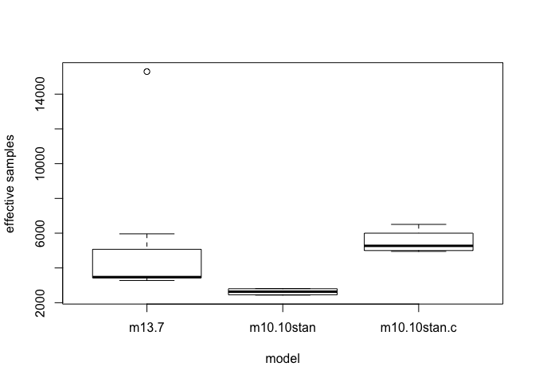

```r
boxplot( list( 'm13.7'=neff_13.7 , 'm10.10stan'=neff_10.10stan, 'm10.10stan.c' = neff_10.10stan.c) ,
         ylab="effective samples" , xlab="model" )
```

## 13H2 Fit a model with varying intercepts and slopes (on age)

### load the data

```r
data(Oxboys)
Oxboys
```

```
##     Subject     age height Occasion
## 1         1 -1.0000 140.50        1
## 2         1 -0.7479 143.40        2
## 3         1 -0.4630 144.80        3
## 4         1 -0.1643 147.10        4
## 5         1 -0.0027 147.70        5
## 6         1  0.2466 150.20        6
## 7         1  0.5562 151.70        7
## 8         1  0.7781 153.30        8
## 9         1  0.9945 155.80        9
## 10        2 -1.0000 136.90        1
## 11        2 -0.7479 139.10        2
## 12        2 -0.4630 140.10        3
## 13        2 -0.1643 142.60        4
## 14        2 -0.0027 143.20        5
```

[output cut: 220 more lines]

```r
str(Oxboys)
```

```
## 'data.frame':    234 obs. of  4 variables:
##  $ Subject : int  1 1 1 1 1 1 1 1 1 2 ...
##  $ age     : num  -1 -0.7479 -0.463 -0.1643 -0.0027 ...
##  $ height  : num  140 143 145 147 148 ...
##  $ Occasion: int  1 2 3 4 5 6 7 8 9 1 ...
```

```r
summary(Oxboys)
```

```
##     Subject          age               height         Occasion
##  Min.   : 1.0   Min.   :-1.00000   Min.   :126.2   Min.   :1
##  1st Qu.: 7.0   1st Qu.:-0.46300   1st Qu.:143.8   1st Qu.:3
##  Median :13.5   Median :-0.00270   Median :149.5   Median :5
##  Mean   :13.5   Mean   : 0.02263   Mean   :149.5   Mean   :5
##  3rd Qu.:20.0   3rd Qu.: 0.55620   3rd Qu.:155.5   3rd Qu.:7
##  Max.   :26.0   Max.   : 1.00550   Max.   :174.8   Max.   :9
```

### Fit the model

```r
m13H2 <- map2stan(
  alist(
    height ~ dnorm( mu , sigma ),
    mu <- a_subject[Subject] + b_subject[Subject]*age,
    c(a_subject,b_subject)[Subject] ~ dmvnorm2(c(a,b),sigma_subject,Rho),
    a ~ dnorm(150,30),
    b ~ dnorm(0,10),
    sigma_subject ~ dcauchy(0,2),
    sigma ~ dcauchy(0,2),
    Rho ~ dlkjcorr(2)
  ) ,
  data=Oxboys ,
  iter=5000 , warmup=2000 , chains=2 )
```

[output not shown]

```
## The following numerical problems occured the indicated number of times on chain 1
```

```
##                                                                        count
## Exception thrown at line 33: lkj_corr_log: y is not positive definite.     2
```

```
## When a numerical problem occurs, the Hamiltonian proposal gets rejected.
```

```
## See http://mc-stan.org/misc/warnings.html#exception-hamiltonian-proposal-rejected
```

```
## If the number in the 'count' column is small, do not ask about this message on stan-users.
```

[output not shown]

```
## The following numerical problems occured the indicated number of times on chain 2
```

```
##                                                                        count
## Exception thrown at line 33: lkj_corr_log: y is not positive definite.     1
```

```
## When a numerical problem occurs, the Hamiltonian proposal gets rejected.
```

```
## See http://mc-stan.org/misc/warnings.html#exception-hamiltonian-proposal-rejected
```

```
## If the number in the 'count' column is small, do not ask about this message on stan-users.
```

```
##
## WARNING: No variance estimation is
##          performed for num_warmup < 20
##
##
## Chain 1, Iteration: 1 / 1 [100%]  (Sampling)
##  Elapsed Time: 3e-06 seconds (Warm-up)
##                0.000153 seconds (Sampling)
##                0.000156 seconds (Total)
```

```
## Computing WAIC
```

```
## Constructing posterior predictions
```

[output not shown]

### look into this model

```r
precis(m13H2,depth = 2)
```

```
##                    Mean StdDev lower 0.89 upper 0.89 n_eff Rhat
## b_subject[1]       7.12   0.33       6.61       7.67  6000    1
## b_subject[2]       5.46   0.33       4.93       5.98  6000    1
## b_subject[3]       4.92   0.33       4.37       5.41  6000    1
## b_subject[4]       9.30   0.34       8.79       9.84  6000    1
## b_subject[5]       6.28   0.33       5.73       6.76  6000    1
## b_subject[6]       4.11   0.34       3.55       4.62  6000    1
## b_subject[7]       5.05   0.33       4.53       5.59  6000    1
## b_subject[8]       6.46   0.33       5.93       6.97  6000    1
## b_subject[9]       5.96   0.34       5.45       6.54  6000    1
## b_subject[10]      3.76   0.34       3.21       4.28  6000    1
## b_subject[11]      8.38   0.34       7.86       8.93  6000    1
## b_subject[12]      7.04   0.33       6.54       7.58  6000    1
## b_subject[13]      8.42   0.34       7.92       9.00  6000    1
## b_subject[14]      8.61   0.33       8.11       9.16  6000    1
## b_subject[15]      7.05   0.34       6.52       7.60  6000    1
## b_subject[16]      4.65   0.33       4.10       5.16  6000    1
## b_subject[17]      8.44   0.33       7.89       8.95  6000    1
## b_subject[18]      6.01   0.34       5.46       6.54  6000    1
## b_subject[19]      9.02   0.33       8.49       9.54  6000    1
## b_subject[20]      4.52   0.34       3.96       5.03  6000    1
## b_subject[21]      7.44   0.34       6.91       8.00  6000    1
## b_subject[22]      8.02   0.34       7.47       8.57  6000    1
## b_subject[23]      7.16   0.33       6.65       7.69  6000    1
## b_subject[24]      6.78   0.33       6.26       7.31  6000    1
## b_subject[25]      4.10   0.33       3.59       4.65  6000    1
## b_subject[26]      5.56   0.33       5.02       6.07  6000    1
## a_subject[1]     148.13   0.22     147.79     148.49  6000    1
## a_subject[2]     142.86   0.22     142.52     143.22  6000    1
## a_subject[3]     155.64   0.22     155.28     155.99  6000    1
## a_subject[4]     165.06   0.22     164.76     165.44  6000    1
## a_subject[5]     151.43   0.22     151.06     151.75  6000    1
## a_subject[6]     146.78   0.22     146.43     147.14  6000    1
## a_subject[7]     146.12   0.22     145.77     146.48  6000    1
## a_subject[8]     148.29   0.22     147.93     148.65  6000    1
## a_subject[9]     138.15   0.22     137.79     138.50  6000    1
## a_subject[10]    130.28   0.23     129.93     130.65  6000    1
## a_subject[11]    150.06   0.23     149.70     150.42  6000    1
## a_subject[12]    156.80   0.22     156.45     157.15  6000    1
## a_subject[13]    156.07   0.22     155.71     156.42  6000    1
## a_subject[14]    159.47   0.22     159.10     159.80  6000    1
## a_subject[15]    144.29   0.22     143.92     144.62  6000    1
## a_subject[16]    147.54   0.22     147.19     147.91  6000    1
## a_subject[17]    142.99   0.22     142.64     143.35  6000    1
## a_subject[18]    151.17   0.22     150.81     151.50  6000    1
## a_subject[19]    164.56   0.22     164.22     164.93  6000    1
## a_subject[20]    151.47   0.22     151.10     151.80  6000    1
## a_subject[21]    150.52   0.22     150.18     150.87  6000    1
## a_subject[22]    154.56   0.22     154.22     154.92  6000    1
## a_subject[23]    151.06   0.22     150.72     151.42  6000    1
## a_subject[24]    153.14   0.22     152.78     153.48  6000    1
## a_subject[25]    139.21   0.22     138.86     139.56  6000    1
## a_subject[26]    138.00   0.22     137.68     138.38  6000    1
## a                149.35   1.63     146.66     151.83  4952    1
## b                  6.51   0.35       5.97       7.07  5193    1
## sigma_subject[1]   8.09   1.12       6.30       9.77  6000    1
## sigma_subject[2]   1.70   0.25       1.31       2.07  4549    1
## sigma              0.66   0.04       0.61       0.72  6000    1
## Rho[1,1]           1.00   0.00       1.00       1.00  6000  NaN
## Rho[1,2]           0.55   0.13       0.35       0.75  6000    1
## Rho[2,1]           0.55   0.13       0.35       0.75  6000    1
## Rho[2,2]           1.00   0.00       1.00       1.00  5048    1
```

## 13H3 Now consider the correlation between the varying intercepts and slopes

### Plot the correlation between the varying intercepts and slopes

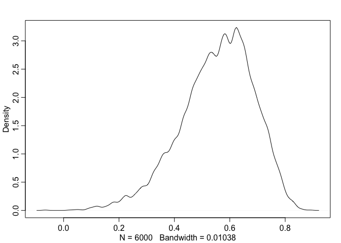

```r
postH2 <- extract.samples(m13H2)
dens( postH2$Rho[,1,2] )
```

### The correlation value is positive, so may be I would predict that in the same subject who was older that might have a taller height???